# Risk Factor Analysis

## Outcome Variable

**Outcome Variable:** sstunted

## Predictor Variables

**Intervention Variable:** feducyrs

**Adjustment Set:**

unadjusted

## Stratifying Variables

The analysis was stratified on these variable(s):

- agecat
- studyid
- country

## Data Summary

| agecat | studyid | country | A | n | nA | nAY0 | nAY1 |
| --- | --- | --- | --- | --- | --- | --- | --- |
| Birth | ki0047075b-MAL-ED | BANGLADESH | Q4 | 144 | 52 | 49 | 3 |
| Birth | ki0047075b-MAL-ED | BANGLADESH | Q1 | 144 | 29 | 28 | 1 |
| Birth | ki0047075b-MAL-ED | BANGLADESH | Q2 | 144 | 9 | 9 | 0 |
| Birth | ki0047075b-MAL-ED | BANGLADESH | Q3 | 144 | 54 | 52 | 2 |
| Birth | ki0047075b-MAL-ED | INDIA | Q4 | 123 | 38 | 38 | 0 |
| Birth | ki0047075b-MAL-ED | INDIA | Q1 | 123 | 21 | 20 | 1 |
| Birth | ki0047075b-MAL-ED | INDIA | Q2 | 123 | 37 | 36 | 1 |
| Birth | ki0047075b-MAL-ED | INDIA | Q3 | 123 | 27 | 26 | 1 |
| Birth | ki0047075b-MAL-ED | NEPAL | Q4 | 67 | 27 | 27 | 0 |
| Birth | ki0047075b-MAL-ED | NEPAL | Q1 | 67 | 18 | 17 | 1 |
| Birth | ki0047075b-MAL-ED | NEPAL | Q2 | 67 | 17 | 14 | 3 |
| Birth | ki0047075b-MAL-ED | NEPAL | Q3 | 67 | 5 | 5 | 0 |
| Birth | ki0047075b-MAL-ED | PERU | Q4 | 236 | 116 | 113 | 3 |
| Birth | ki0047075b-MAL-ED | PERU | Q1 | 236 | 47 | 45 | 2 |
| Birth | ki0047075b-MAL-ED | PERU | Q2 | 236 | 62 | 61 | 1 |
| Birth | ki0047075b-MAL-ED | PERU | Q3 | 236 | 11 | 11 | 0 |
| Birth | ki0047075b-MAL-ED | SOUTH AFRICA | Q4 | 91 | 35 | 35 | 0 |
| Birth | ki0047075b-MAL-ED | SOUTH AFRICA | Q1 | 91 | 15 | 15 | 0 |
| Birth | ki0047075b-MAL-ED | SOUTH AFRICA | Q2 | 91 | 22 | 22 | 0 |
| Birth | ki0047075b-MAL-ED | SOUTH AFRICA | Q3 | 91 | 19 | 19 | 0 |
| Birth | ki0047075b-MAL-ED | TANZANIA, UNITED REPUBLIC OF | Q4 | 101 | 3 | 3 | 0 |
| Birth | ki0047075b-MAL-ED | TANZANIA, UNITED REPUBLIC OF | Q1 | 101 | 20 | 19 | 1 |
| Birth | ki0047075b-MAL-ED | TANZANIA, UNITED REPUBLIC OF | Q2 | 101 | 16 | 14 | 2 |
| Birth | ki0047075b-MAL-ED | TANZANIA, UNITED REPUBLIC OF | Q3 | 101 | 62 | 59 | 3 |
| Birth | ki1000304b-SAS-CompFeed | INDIA | Q4 | 70 | 11 | 11 | 0 |
| Birth | ki1000304b-SAS-CompFeed | INDIA | Q1 | 70 | 11 | 10 | 1 |
| Birth | ki1000304b-SAS-CompFeed | INDIA | Q2 | 70 | 26 | 25 | 1 |
| Birth | ki1000304b-SAS-CompFeed | INDIA | Q3 | 70 | 22 | 20 | 2 |
| Birth | ki1017093c-NIH-Crypto | BANGLADESH | Q4 | 27 | 5 | 5 | 0 |
| Birth | ki1017093c-NIH-Crypto | BANGLADESH | Q1 | 27 | 4 | 4 | 0 |

[output cut: 486 more lines]

The following strata were considered:

- agecat: 12 months, studyid: ki0047075b-MAL-ED, country: BANGLADESH
- agecat: 12 months, studyid: ki0047075b-MAL-ED, country: INDIA
- agecat: 12 months, studyid: ki0047075b-MAL-ED, country: NEPAL
- agecat: 12 months, studyid: ki0047075b-MAL-ED, country: PERU
- agecat: 12 months, studyid: ki0047075b-MAL-ED, country: SOUTH AFRICA
- agecat: 12 months, studyid: ki0047075b-MAL-ED, country: TANZANIA, UNITED REPUBLIC OF
- agecat: 12 months, studyid: ki1000304b-SAS-CompFeed, country: INDIA
- agecat: 12 months, studyid: ki1000304b-SAS-FoodSuppl, country: INDIA
- agecat: 12 months, studyid: ki1017093b-PROVIDE, country: BANGLADESH
- agecat: 12 months, studyid: ki1017093c-NIH-Crypto, country: BANGLADESH
- agecat: 12 months, studyid: ki1066203-TanzaniaChild2, country: TANZANIA, UNITED REPUBLIC OF
- agecat: 12 months, studyid: ki1113344-GMS-Nepal, country: NEPAL
- agecat: 12 months, studyid: ki1119695-PROBIT, country: BELARUS
- agecat: 12 months, studyid: ki1126311-ZVITAMBO, country: ZIMBABWE
- agecat: 12 months, studyid: ki1135781-COHORTS, country: GUATEMALA
- agecat: 12 months, studyid: ki1135781-COHORTS, country: INDIA
- agecat: 12 months, studyid: ki1135781-COHORTS, country: PHILIPPINES
- agecat: 12 months, studyid: ki1148112-LCNI-5, country: MALAWI
- agecat: 12 months, studyid: kiGH5241-JiVitA-3, country: BANGLADESH
- agecat: 12 months, studyid: kiGH5241-JiVitA-4, country: BANGLADESH
- agecat: 18 months, studyid: ki0047075b-MAL-ED, country: BANGLADESH
- agecat: 18 months, studyid: ki0047075b-MAL-ED, country: INDIA
- agecat: 18 months, studyid: ki0047075b-MAL-ED, country: NEPAL
- agecat: 18 months, studyid: ki0047075b-MAL-ED, country: PERU
- agecat: 18 months, studyid: ki0047075b-MAL-ED, country: SOUTH AFRICA
- agecat: 18 months, studyid: ki0047075b-MAL-ED, country: TANZANIA, UNITED REPUBLIC OF
- agecat: 18 months, studyid: ki1000304b-SAS-CompFeed, country: INDIA
- agecat: 18 months, studyid: ki1000304b-SAS-FoodSuppl, country: INDIA
- agecat: 18 months, studyid: ki1017093b-PROVIDE, country: BANGLADESH
- agecat: 18 months, studyid: ki1017093c-NIH-Crypto, country: BANGLADESH
- agecat: 18 months, studyid: ki1066203-TanzaniaChild2, country: TANZANIA, UNITED REPUBLIC OF
- agecat: 18 months, studyid: ki1113344-GMS-Nepal, country: NEPAL
- agecat: 18 months, studyid: ki1119695-PROBIT, country: BELARUS
- agecat: 18 months, studyid: ki1126311-ZVITAMBO, country: ZIMBABWE
- agecat: 18 months, studyid: ki1135781-COHORTS, country: GUATEMALA
- agecat: 18 months, studyid: ki1135781-COHORTS, country: PHILIPPINES
- agecat: 18 months, studyid: ki1148112-LCNI-5, country: MALAWI
- agecat: 18 months, studyid: kiGH5241-JiVitA-4, country: BANGLADESH
- agecat: 24 months, studyid: ki0047075b-MAL-ED, country: BANGLADESH
- agecat: 24 months, studyid: ki0047075b-MAL-ED, country: INDIA
- agecat: 24 months, studyid: ki0047075b-MAL-ED, country: NEPAL
- agecat: 24 months, studyid: ki0047075b-MAL-ED, country: PERU
- agecat: 24 months, studyid: ki0047075b-MAL-ED, country: SOUTH AFRICA
- agecat: 24 months, studyid: ki0047075b-MAL-ED, country: TANZANIA, UNITED REPUBLIC OF
- agecat: 24 months, studyid: ki1017093b-PROVIDE, country: BANGLADESH
- agecat: 24 months, studyid: ki1017093c-NIH-Crypto, country: BANGLADESH
- agecat: 24 months, studyid: ki1066203-TanzaniaChild2, country: TANZANIA, UNITED REPUBLIC OF
- agecat: 24 months, studyid: ki1113344-GMS-Nepal, country: NEPAL
- agecat: 24 months, studyid: ki1119695-PROBIT, country: BELARUS
- agecat: 24 months, studyid: ki1126311-ZVITAMBO, country: ZIMBABWE
- agecat: 24 months, studyid: ki1135781-COHORTS, country: GUATEMALA
- agecat: 24 months, studyid: ki1135781-COHORTS, country: INDIA
- agecat: 24 months, studyid: ki1135781-COHORTS, country: PHILIPPINES
- agecat: 24 months, studyid: ki1148112-LCNI-5, country: MALAWI
- agecat: 24 months, studyid: kiGH5241-JiVitA-3, country: BANGLADESH
- agecat: 24 months, studyid: kiGH5241-JiVitA-4, country: BANGLADESH
- agecat: 3 months, studyid: ki0047075b-MAL-ED, country: BANGLADESH
- agecat: 3 months, studyid: ki0047075b-MAL-ED, country: INDIA
- agecat: 3 months, studyid: ki0047075b-MAL-ED, country: NEPAL
- agecat: 3 months, studyid: ki0047075b-MAL-ED, country: PERU
- agecat: 3 months, studyid: ki0047075b-MAL-ED, country: SOUTH AFRICA
- agecat: 3 months, studyid: ki0047075b-MAL-ED, country: TANZANIA, UNITED REPUBLIC OF
- agecat: 3 months, studyid: ki1000304b-SAS-CompFeed, country: INDIA
- agecat: 3 months, studyid: ki1000304b-SAS-FoodSuppl, country: INDIA
- agecat: 3 months, studyid: ki1017093b-PROVIDE, country: BANGLADESH
- agecat: 3 months, studyid: ki1017093c-NIH-Crypto, country: BANGLADESH
- agecat: 3 months, studyid: ki1066203-TanzaniaChild2, country: TANZANIA, UNITED REPUBLIC OF
- agecat: 3 months, studyid: ki1113344-GMS-Nepal, country: NEPAL
- agecat: 3 months, studyid: ki1119695-PROBIT, country: BELARUS
- agecat: 3 months, studyid: ki1126311-ZVITAMBO, country: ZIMBABWE
- agecat: 3 months, studyid: ki1135781-COHORTS, country: GUATEMALA
- agecat: 3 months, studyid: ki1135781-COHORTS, country: INDIA
- agecat: 3 months, studyid: ki1135781-COHORTS, country: PHILIPPINES
- agecat: 3 months, studyid: kiGH5241-JiVitA-3, country: BANGLADESH
- agecat: 3 months, studyid: kiGH5241-JiVitA-4, country: BANGLADESH
- agecat: 6 months, studyid: ki0047075b-MAL-ED, country: BANGLADESH
- agecat: 6 months, studyid: ki0047075b-MAL-ED, country: INDIA
- agecat: 6 months, studyid: ki0047075b-MAL-ED, country: NEPAL
- agecat: 6 months, studyid: ki0047075b-MAL-ED, country: PERU
- agecat: 6 months, studyid: ki0047075b-MAL-ED, country: SOUTH AFRICA
- agecat: 6 months, studyid: ki0047075b-MAL-ED, country: TANZANIA, UNITED REPUBLIC OF
- agecat: 6 months, studyid: ki1000304b-SAS-CompFeed, country: INDIA
- agecat: 6 months, studyid: ki1000304b-SAS-FoodSuppl, country: INDIA
- agecat: 6 months, studyid: ki1017093b-PROVIDE, country: BANGLADESH
- agecat: 6 months, studyid: ki1017093c-NIH-Crypto, country: BANGLADESH
- agecat: 6 months, studyid: ki1066203-TanzaniaChild2, country: TANZANIA, UNITED REPUBLIC OF
- agecat: 6 months, studyid: ki1113344-GMS-Nepal, country: NEPAL
- agecat: 6 months, studyid: ki1119695-PROBIT, country: BELARUS
- agecat: 6 months, studyid: ki1126311-ZVITAMBO, country: ZIMBABWE
- agecat: 6 months, studyid: ki1135781-COHORTS, country: GUATEMALA
- agecat: 6 months, studyid: ki1135781-COHORTS, country: INDIA
- agecat: 6 months, studyid: ki1135781-COHORTS, country: PHILIPPINES
- agecat: 6 months, studyid: ki1148112-LCNI-5, country: MALAWI
- agecat: 6 months, studyid: kiGH5241-JiVitA-3, country: BANGLADESH
- agecat: 6 months, studyid: kiGH5241-JiVitA-4, country: BANGLADESH
- agecat: 9 months, studyid: ki0047075b-MAL-ED, country: BANGLADESH
- agecat: 9 months, studyid: ki0047075b-MAL-ED, country: INDIA
- agecat: 9 months, studyid: ki0047075b-MAL-ED, country: NEPAL
- agecat: 9 months, studyid: ki0047075b-MAL-ED, country: PERU
- agecat: 9 months, studyid: ki0047075b-MAL-ED, country: SOUTH AFRICA
- agecat: 9 months, studyid: ki0047075b-MAL-ED, country: TANZANIA, UNITED REPUBLIC OF
- agecat: 9 months, studyid: ki1000304b-SAS-CompFeed, country: INDIA
- agecat: 9 months, studyid: ki1000304b-SAS-FoodSuppl, country: INDIA
- agecat: 9 months, studyid: ki1017093b-PROVIDE, country: BANGLADESH
- agecat: 9 months, studyid: ki1017093c-NIH-Crypto, country: BANGLADESH
- agecat: 9 months, studyid: ki1066203-TanzaniaChild2, country: TANZANIA, UNITED REPUBLIC OF
- agecat: 9 months, studyid: ki1113344-GMS-Nepal, country: NEPAL
- agecat: 9 months, studyid: ki1119695-PROBIT, country: BELARUS
- agecat: 9 months, studyid: ki1126311-ZVITAMBO, country: ZIMBABWE
- agecat: 9 months, studyid: ki1135781-COHORTS, country: GUATEMALA
- agecat: 9 months, studyid: ki1135781-COHORTS, country: INDIA
- agecat: 9 months, studyid: ki1135781-COHORTS, country: PHILIPPINES
- agecat: 9 months, studyid: ki1148112-LCNI-5, country: MALAWI
- agecat: 9 months, studyid: kiGH5241-JiVitA-4, country: BANGLADESH
- agecat: Birth, studyid: ki0047075b-MAL-ED, country: BANGLADESH
- agecat: Birth, studyid: ki0047075b-MAL-ED, country: INDIA
- agecat: Birth, studyid: ki0047075b-MAL-ED, country: NEPAL
- agecat: Birth, studyid: ki0047075b-MAL-ED, country: PERU
- agecat: Birth, studyid: ki0047075b-MAL-ED, country: SOUTH AFRICA
- agecat: Birth, studyid: ki0047075b-MAL-ED, country: TANZANIA, UNITED REPUBLIC OF
- agecat: Birth, studyid: ki1000304b-SAS-CompFeed, country: INDIA
- agecat: Birth, studyid: ki1017093c-NIH-Crypto, country: BANGLADESH
- agecat: Birth, studyid: ki1119695-PROBIT, country: BELARUS
- agecat: Birth, studyid: ki1126311-ZVITAMBO, country: ZIMBABWE
- agecat: Birth, studyid: ki1135781-COHORTS, country: GUATEMALA
- agecat: Birth, studyid: ki1135781-COHORTS, country: INDIA
- agecat: Birth, studyid: ki1135781-COHORTS, country: PHILIPPINES
- agecat: Birth, studyid: kiGH5241-JiVitA-3, country: BANGLADESH
- agecat: Birth, studyid: kiGH5241-JiVitA-4, country: BANGLADESH

### Dropped Strata

Some strata were dropped due to rare outcomes:

- agecat: Birth, studyid: ki0047075b-MAL-ED, country: BANGLADESH
- agecat: Birth, studyid: ki0047075b-MAL-ED, country: INDIA
- agecat: Birth, studyid: ki0047075b-MAL-ED, country: NEPAL
- agecat: Birth, studyid: ki0047075b-MAL-ED, country: PERU
- agecat: Birth, studyid: ki0047075b-MAL-ED, country: SOUTH AFRICA
- agecat: Birth, studyid: ki0047075b-MAL-ED, country: TANZANIA, UNITED REPUBLIC OF
- agecat: Birth, studyid: ki1000304b-SAS-CompFeed, country: INDIA
- agecat: Birth, studyid: ki1017093c-NIH-Crypto, country: BANGLADESH
- agecat: Birth, studyid: ki1119695-PROBIT, country: BELARUS
- agecat: Birth, studyid: ki1126311-ZVITAMBO, country: ZIMBABWE
- agecat: Birth, studyid: ki1135781-COHORTS, country: GUATEMALA
- agecat: Birth, studyid: ki1135781-COHORTS, country: INDIA
- agecat: Birth, studyid: ki1135781-COHORTS, country: PHILIPPINES
- agecat: Birth, studyid: kiGH5241-JiVitA-4, country: BANGLADESH
- agecat: 3 months, studyid: ki0047075b-MAL-ED, country: BANGLADESH
- agecat: 3 months, studyid: ki0047075b-MAL-ED, country: INDIA
- agecat: 3 months, studyid: ki0047075b-MAL-ED, country: NEPAL
- agecat: 3 months, studyid: ki0047075b-MAL-ED, country: PERU
- agecat: 3 months, studyid: ki0047075b-MAL-ED, country: SOUTH AFRICA
- agecat: 3 months, studyid: ki0047075b-MAL-ED, country: TANZANIA, UNITED REPUBLIC OF
- agecat: 3 months, studyid: ki1000304b-SAS-CompFeed, country: INDIA
- agecat: 3 months, studyid: ki1000304b-SAS-FoodSuppl, country: INDIA
- agecat: 3 months, studyid: ki1017093b-PROVIDE, country: BANGLADESH
- agecat: 3 months, studyid: ki1066203-TanzaniaChild2, country: TANZANIA, UNITED REPUBLIC OF
- agecat: 3 months, studyid: ki1113344-GMS-Nepal, country: NEPAL
- agecat: 3 months, studyid: ki1119695-PROBIT, country: BELARUS
- agecat: 3 months, studyid: ki1126311-ZVITAMBO, country: ZIMBABWE
- agecat: 3 months, studyid: ki1135781-COHORTS, country: GUATEMALA
- agecat: 3 months, studyid: ki1135781-COHORTS, country: INDIA
- agecat: 3 months, studyid: kiGH5241-JiVitA-4, country: BANGLADESH
- agecat: 6 months, studyid: ki0047075b-MAL-ED, country: BANGLADESH
- agecat: 6 months, studyid: ki0047075b-MAL-ED, country: INDIA
- agecat: 6 months, studyid: ki0047075b-MAL-ED, country: NEPAL
- agecat: 6 months, studyid: ki0047075b-MAL-ED, country: PERU
- agecat: 6 months, studyid: ki0047075b-MAL-ED, country: SOUTH AFRICA
- agecat: 6 months, studyid: ki0047075b-MAL-ED, country: TANZANIA, UNITED REPUBLIC OF
- agecat: 6 months, studyid: ki1000304b-SAS-FoodSuppl, country: INDIA
- agecat: 6 months, studyid: ki1017093b-PROVIDE, country: BANGLADESH
- agecat: 6 months, studyid: ki1017093c-NIH-Crypto, country: BANGLADESH
- agecat: 6 months, studyid: ki1066203-TanzaniaChild2, country: TANZANIA, UNITED REPUBLIC OF
- agecat: 6 months, studyid: ki1113344-GMS-Nepal, country: NEPAL
- agecat: 6 months, studyid: ki1119695-PROBIT, country: BELARUS
- agecat: 6 months, studyid: ki1126311-ZVITAMBO, country: ZIMBABWE
- agecat: 6 months, studyid: ki1135781-COHORTS, country: GUATEMALA
- agecat: 6 months, studyid: ki1148112-LCNI-5, country: MALAWI
- agecat: 6 months, studyid: kiGH5241-JiVitA-4, country: BANGLADESH
- agecat: 9 months, studyid: ki0047075b-MAL-ED, country: BANGLADESH
- agecat: 9 months, studyid: ki0047075b-MAL-ED, country: INDIA
- agecat: 9 months, studyid: ki0047075b-MAL-ED, country: NEPAL
- agecat: 9 months, studyid: ki0047075b-MAL-ED, country: PERU
- agecat: 9 months, studyid: ki0047075b-MAL-ED, country: SOUTH AFRICA
- agecat: 9 months, studyid: ki0047075b-MAL-ED, country: TANZANIA, UNITED REPUBLIC OF
- agecat: 9 months, studyid: ki1000304b-SAS-FoodSuppl, country: INDIA
- agecat: 9 months, studyid: ki1017093b-PROVIDE, country: BANGLADESH
- agecat: 9 months, studyid: ki1017093c-NIH-Crypto, country: BANGLADESH
- agecat: 9 months, studyid: ki1066203-TanzaniaChild2, country: TANZANIA, UNITED REPUBLIC OF
- agecat: 9 months, studyid: ki1113344-GMS-Nepal, country: NEPAL
- agecat: 9 months, studyid: ki1119695-PROBIT, country: BELARUS
- agecat: 9 months, studyid: ki1126311-ZVITAMBO, country: ZIMBABWE
- agecat: 9 months, studyid: ki1135781-COHORTS, country: GUATEMALA
- agecat: 9 months, studyid: ki1148112-LCNI-5, country: MALAWI
- agecat: 9 months, studyid: kiGH5241-JiVitA-4, country: BANGLADESH
- agecat: 12 months, studyid: ki0047075b-MAL-ED, country: BANGLADESH
- agecat: 12 months, studyid: ki0047075b-MAL-ED, country: INDIA
- agecat: 12 months, studyid: ki0047075b-MAL-ED, country: NEPAL
- agecat: 12 months, studyid: ki0047075b-MAL-ED, country: PERU
- agecat: 12 months, studyid: ki0047075b-MAL-ED, country: SOUTH AFRICA
- agecat: 12 months, studyid: ki0047075b-MAL-ED, country: TANZANIA, UNITED REPUBLIC OF
- agecat: 12 months, studyid: ki1000304b-SAS-FoodSuppl, country: INDIA
- agecat: 12 months, studyid: ki1017093b-PROVIDE, country: BANGLADESH
- agecat: 12 months, studyid: ki1066203-TanzaniaChild2, country: TANZANIA, UNITED REPUBLIC OF
- agecat: 12 months, studyid: ki1113344-GMS-Nepal, country: NEPAL
- agecat: 12 months, studyid: ki1119695-PROBIT, country: BELARUS
- agecat: 12 months, studyid: ki1135781-COHORTS, country: GUATEMALA
- agecat: 12 months, studyid: ki1148112-LCNI-5, country: MALAWI
- agecat: 12 months, studyid: kiGH5241-JiVitA-4, country: BANGLADESH
- agecat: 18 months, studyid: ki0047075b-MAL-ED, country: BANGLADESH
- agecat: 18 months, studyid: ki0047075b-MAL-ED, country: INDIA
- agecat: 18 months, studyid: ki0047075b-MAL-ED, country: NEPAL
- agecat: 18 months, studyid: ki0047075b-MAL-ED, country: PERU
- agecat: 18 months, studyid: ki0047075b-MAL-ED, country: SOUTH AFRICA
- agecat: 18 months, studyid: ki0047075b-MAL-ED, country: TANZANIA, UNITED REPUBLIC OF
- agecat: 18 months, studyid: ki1000304b-SAS-FoodSuppl, country: INDIA
- agecat: 18 months, studyid: ki1017093b-PROVIDE, country: BANGLADESH
- agecat: 18 months, studyid: ki1066203-TanzaniaChild2, country: TANZANIA, UNITED REPUBLIC OF
- agecat: 18 months, studyid: ki1119695-PROBIT, country: BELARUS
- agecat: 18 months, studyid: ki1126311-ZVITAMBO, country: ZIMBABWE
- agecat: 18 months, studyid: ki1135781-COHORTS, country: GUATEMALA
- agecat: 18 months, studyid: kiGH5241-JiVitA-4, country: BANGLADESH
- agecat: 24 months, studyid: ki0047075b-MAL-ED, country: BANGLADESH
- agecat: 24 months, studyid: ki0047075b-MAL-ED, country: INDIA
- agecat: 24 months, studyid: ki0047075b-MAL-ED, country: NEPAL
- agecat: 24 months, studyid: ki0047075b-MAL-ED, country: PERU
- agecat: 24 months, studyid: ki0047075b-MAL-ED, country: SOUTH AFRICA
- agecat: 24 months, studyid: ki0047075b-MAL-ED, country: TANZANIA, UNITED REPUBLIC OF
- agecat: 24 months, studyid: ki1017093b-PROVIDE, country: BANGLADESH
- agecat: 24 months, studyid: ki1066203-TanzaniaChild2, country: TANZANIA, UNITED REPUBLIC OF
- agecat: 24 months, studyid: ki1119695-PROBIT, country: BELARUS
- agecat: 24 months, studyid: ki1126311-ZVITAMBO, country: ZIMBABWE
- agecat: 24 months, studyid: ki1135781-COHORTS, country: GUATEMALA
- agecat: 24 months, studyid: ki1148112-LCNI-5, country: MALAWI
- agecat: 24 months, studyid: kiGH5241-JiVitA-4, country: BANGLADESH

## Methods Detail

We’re interested in the causal parameters $E[Y_a]$ for all values of $a \in \mathcal{A}$. These parameters represent the mean outcome if, possibly contrary to fact, we intervened to set all units to have $A=a$. Under the randomization and positivity assumptions, these are identified by the statistical parameters $\psi_a=E_W[E_{Y|A,W}(Y|A=a,W)]$. In addition, we’re interested in the mean of $Y$, $E[Y]$ under no intervention (the observed mean). We will estimate these parameters by using SuperLearner to fit the relevant likelihood factors – $E_{Y|A,W}(Y|A=a,W)$ and $p(A=a|W)$, and then updating our likelihood fit using a joint TMLE.

For unadjusted analyses ($W=\{\}$), initial likelihoods were estimated using Lrnr_glm to estimate the simple $E(Y|A)$ and Lrnr_mean to estimate $p(A)$. For adjusted analyses, a small library containing Lrnr_glmnet, Lrnr_xgboost, and Lrnr_mean was used.

Having estimated these parameters, we will then use the delta method to estimate relative risks and attributable risks relative to a prespecified baseline level of $A$.

# Results Detail

## Results Plots

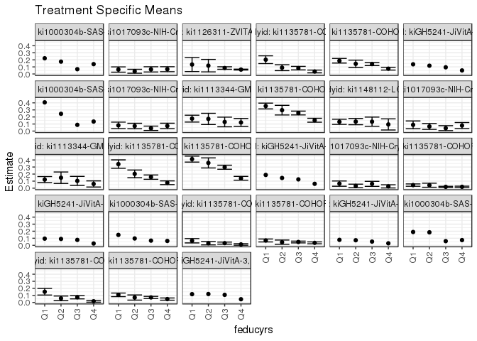

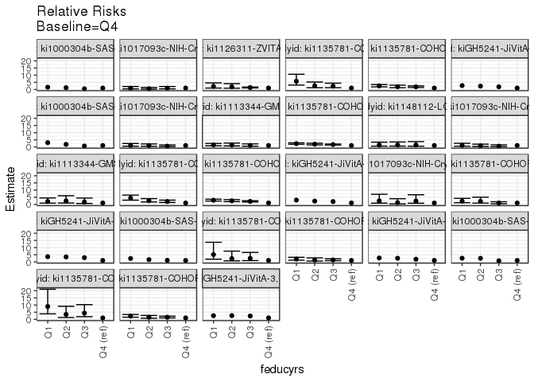

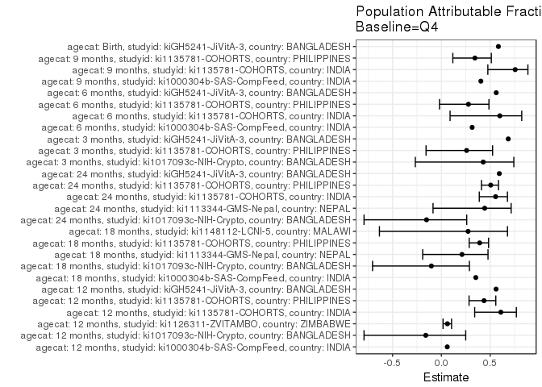

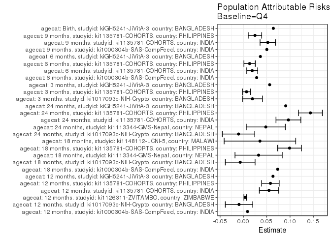

## Results Table

### Parameter: TSM

| agecat | studyid | country | intervention_level | baseline_level | estimate | ci_lower | ci_upper |
| --- | --- | --- | --- | --- | --- | --- | --- |
| Birth | kiGH5241-JiVitA-3 | BANGLADESH | Q4 | NA | 0.0457604 | NA | NA |
| Birth | kiGH5241-JiVitA-3 | BANGLADESH | Q1 | NA | 0.1173366 | NA | NA |
| Birth | kiGH5241-JiVitA-3 | BANGLADESH | Q2 | NA | 0.1193604 | NA | NA |
| Birth | kiGH5241-JiVitA-3 | BANGLADESH | Q3 | NA | 0.1075269 | NA | NA |
| 3 months | ki1017093c-NIH-Crypto | BANGLADESH | Q4 | NA | 0.0259067 | 0.0034796 | 0.0483339 |
| 3 months | ki1017093c-NIH-Crypto | BANGLADESH | Q1 | NA | 0.0650888 | 0.0278718 | 0.1023058 |
| 3 months | ki1017093c-NIH-Crypto | BANGLADESH | Q2 | NA | 0.0319149 | 0.0067717 | 0.0570581 |
| 3 months | ki1017093c-NIH-Crypto | BANGLADESH | Q3 | NA | 0.0617978 | 0.0264004 | 0.0971951 |
| 3 months | ki1135781-COHORTS | PHILIPPINES | Q4 | NA | 0.0193798 | 0.0096662 | 0.0290935 |
| 3 months | ki1135781-COHORTS | PHILIPPINES | Q1 | NA | 0.0439932 | 0.0274562 | 0.0605303 |
| 3 months | ki1135781-COHORTS | PHILIPPINES | Q2 | NA | 0.0421053 | 0.0135439 | 0.0706666 |
| 3 months | ki1135781-COHORTS | PHILIPPINES | Q3 | NA | 0.0189329 | 0.0110953 | 0.0267705 |
| 3 months | kiGH5241-JiVitA-3 | BANGLADESH | Q4 | NA | 0.0259146 | NA | NA |
| 3 months | kiGH5241-JiVitA-3 | BANGLADESH | Q1 | NA | 0.0946870 | NA | NA |
| 3 months | kiGH5241-JiVitA-3 | BANGLADESH | Q2 | NA | 0.0904476 | NA | NA |
| 3 months | kiGH5241-JiVitA-3 | BANGLADESH | Q3 | NA | 0.0769517 | NA | NA |
| 6 months | ki1000304b-SAS-CompFeed | INDIA | Q4 | NA | 0.0619469 | NA | NA |
| 6 months | ki1000304b-SAS-CompFeed | INDIA | Q1 | NA | 0.1477273 | NA | NA |
| 6 months | ki1000304b-SAS-CompFeed | INDIA | Q2 | NA | 0.0970874 | NA | NA |
| 6 months | ki1000304b-SAS-CompFeed | INDIA | Q3 | NA | 0.0666667 | NA | NA |
| 6 months | ki1135781-COHORTS | INDIA | Q4 | NA | 0.0127551 | 0.0016425 | 0.0238677 |
| 6 months | ki1135781-COHORTS | INDIA | Q1 | NA | 0.0647773 | 0.0340712 | 0.0954835 |
| 6 months | ki1135781-COHORTS | INDIA | Q2 | NA | 0.0295567 | 0.0062505 | 0.0528628 |
| 6 months | ki1135781-COHORTS | INDIA | Q3 | NA | 0.0313076 | 0.0166547 | 0.0459604 |
| 6 months | ki1135781-COHORTS | PHILIPPINES | Q4 | NA | 0.0349650 | 0.0214981 | 0.0484320 |
| 6 months | ki1135781-COHORTS | PHILIPPINES | Q1 | NA | 0.0687831 | 0.0479474 | 0.0896187 |
| 6 months | ki1135781-COHORTS | PHILIPPINES | Q2 | NA | 0.0446927 | 0.0144169 | 0.0749686 |
| 6 months | ki1135781-COHORTS | PHILIPPINES | Q3 | NA | 0.0471442 | 0.0346337 | 0.0596546 |
| 6 months | kiGH5241-JiVitA-3 | BANGLADESH | Q4 | NA | 0.0285088 | NA | NA |
| 6 months | kiGH5241-JiVitA-3 | BANGLADESH | Q1 | NA | 0.0775068 | NA | NA |

[output cut: 78 more lines]

### Parameter: E(Y)

| agecat | studyid | country | intervention_level | baseline_level | estimate | ci_lower | ci_upper |
| --- | --- | --- | --- | --- | --- | --- | --- |
| Birth | kiGH5241-JiVitA-3 | BANGLADESH | NA | NA | 0.1099968 | NA | NA |
| 3 months | ki1017093c-NIH-Crypto | BANGLADESH | NA | NA | 0.0453297 | 0.0302080 | 0.0604513 |
| 3 months | ki1135781-COHORTS | PHILIPPINES | NA | NA | 0.0261318 | 0.0201322 | 0.0321313 |
| 3 months | kiGH5241-JiVitA-3 | BANGLADESH | NA | NA | 0.0822945 | NA | NA |
| 6 months | ki1000304b-SAS-CompFeed | INDIA | NA | NA | 0.0904645 | NA | NA |
| 6 months | ki1135781-COHORTS | INDIA | NA | NA | 0.0317690 | 0.0225290 | 0.0410089 |
| 6 months | ki1135781-COHORTS | PHILIPPINES | NA | NA | 0.0483619 | 0.0400565 | 0.0566674 |
| 6 months | kiGH5241-JiVitA-3 | BANGLADESH | NA | NA | 0.0650376 | NA | NA |
| 9 months | ki1000304b-SAS-CompFeed | INDIA | NA | NA | 0.1243781 | NA | NA |
| 9 months | ki1135781-COHORTS | INDIA | NA | NA | 0.0692675 | 0.0552199 | 0.0833152 |
| 9 months | ki1135781-COHORTS | PHILIPPINES | NA | NA | 0.0725146 | 0.0624764 | 0.0825528 |
| 12 months | ki1000304b-SAS-CompFeed | INDIA | NA | NA | 0.1480583 | NA | NA |
| 12 months | ki1017093c-NIH-Crypto | BANGLADESH | NA | NA | 0.0580737 | 0.0408093 | 0.0753381 |
| 12 months | ki1126311-ZVITAMBO | ZIMBABWE | NA | NA | 0.0658116 | 0.0598059 | 0.0718173 |
| 12 months | ki1135781-COHORTS | INDIA | NA | NA | 0.0902954 | 0.0739703 | 0.1066204 |
| 12 months | ki1135781-COHORTS | PHILIPPINES | NA | NA | 0.1328157 | 0.1193664 | 0.1462650 |
| 12 months | kiGH5241-JiVitA-3 | BANGLADESH | NA | NA | 0.1133738 | NA | NA |
| 18 months | ki1000304b-SAS-CompFeed | INDIA | NA | NA | 0.2086514 | NA | NA |
| 18 months | ki1017093c-NIH-Crypto | BANGLADESH | NA | NA | 0.0662461 | 0.0468710 | 0.0856211 |
| 18 months | ki1113344-GMS-Nepal | NEPAL | NA | NA | 0.1548270 | 0.1245401 | 0.1851138 |
| 18 months | ki1135781-COHORTS | PHILIPPINES | NA | NA | 0.2526539 | 0.2351002 | 0.2702076 |
| 18 months | ki1148112-LCNI-5 | MALAWI | NA | NA | 0.1298883 | 0.1052467 | 0.1545298 |
| 24 months | ki1017093c-NIH-Crypto | BANGLADESH | NA | NA | 0.0680934 | 0.0462948 | 0.0898920 |
| 24 months | ki1113344-GMS-Nepal | NEPAL | NA | NA | 0.1084337 | 0.0810981 | 0.1357694 |
| 24 months | ki1135781-COHORTS | INDIA | NA | NA | 0.1739130 | 0.1539078 | 0.1939183 |
| 24 months | ki1135781-COHORTS | PHILIPPINES | NA | NA | 0.2843561 | 0.2659721 | 0.3027401 |
| 24 months | kiGH5241-JiVitA-3 | BANGLADESH | NA | NA | 0.1530439 | NA | NA |

### Parameter: RR

| agecat | studyid | country | intervention_level | baseline_level | estimate | ci_lower | ci_upper |
| --- | --- | --- | --- | --- | --- | --- | --- |
| Birth | kiGH5241-JiVitA-3 | BANGLADESH | Q4 | Q4 | 1.0000000 | NA | NA |
| Birth | kiGH5241-JiVitA-3 | BANGLADESH | Q1 | Q4 | 2.5641494 | NA | NA |
| Birth | kiGH5241-JiVitA-3 | BANGLADESH | Q2 | Q4 | 2.6083750 | NA | NA |
| Birth | kiGH5241-JiVitA-3 | BANGLADESH | Q3 | Q4 | 2.3497786 | NA | NA |
| 3 months | ki1017093c-NIH-Crypto | BANGLADESH | Q4 | Q4 | 1.0000000 | 1.0000000 | 1.000000 |
| 3 months | ki1017093c-NIH-Crypto | BANGLADESH | Q1 | Q4 | 2.5124260 | 0.8902717 | 7.090290 |
| 3 months | ki1017093c-NIH-Crypto | BANGLADESH | Q2 | Q4 | 1.2319149 | 0.3821530 | 3.971222 |
| 3 months | ki1017093c-NIH-Crypto | BANGLADESH | Q3 | Q4 | 2.3853933 | 0.8447894 | 6.735526 |
| 3 months | ki1135781-COHORTS | PHILIPPINES | Q4 | Q4 | 1.0000000 | 1.0000000 | 1.000000 |
| 3 months | ki1135781-COHORTS | PHILIPPINES | Q1 | Q4 | 2.2700507 | 1.2132253 | 4.247464 |
| 3 months | ki1135781-COHORTS | PHILIPPINES | Q2 | Q4 | 2.1726316 | 0.9347441 | 5.049861 |
| 3 months | ki1135781-COHORTS | PHILIPPINES | Q3 | Q4 | 0.9769363 | 0.5099680 | 1.871499 |
| 3 months | kiGH5241-JiVitA-3 | BANGLADESH | Q4 | Q4 | 1.0000000 | NA | NA |
| 3 months | kiGH5241-JiVitA-3 | BANGLADESH | Q1 | Q4 | 3.6538045 | NA | NA |
| 3 months | kiGH5241-JiVitA-3 | BANGLADESH | Q2 | Q4 | 3.4902142 | NA | NA |
| 3 months | kiGH5241-JiVitA-3 | BANGLADESH | Q3 | Q4 | 2.9694293 | NA | NA |
| 6 months | ki1000304b-SAS-CompFeed | INDIA | Q4 | Q4 | 1.0000000 | NA | NA |
| 6 months | ki1000304b-SAS-CompFeed | INDIA | Q1 | Q4 | 2.3847403 | NA | NA |
| 6 months | ki1000304b-SAS-CompFeed | INDIA | Q2 | Q4 | 1.5672677 | NA | NA |
| 6 months | ki1000304b-SAS-CompFeed | INDIA | Q3 | Q4 | 1.0761905 | NA | NA |
| 6 months | ki1135781-COHORTS | INDIA | Q4 | Q4 | 1.0000000 | 1.0000000 | 1.000000 |
| 6 months | ki1135781-COHORTS | INDIA | Q1 | Q4 | 5.0785425 | 1.8836042 | 13.692682 |
| 6 months | ki1135781-COHORTS | INDIA | Q2 | Q4 | 2.3172414 | 0.7155522 | 7.504146 |
| 6 months | ki1135781-COHORTS | INDIA | Q3 | Q4 | 2.4545120 | 0.9129653 | 6.598968 |
| 6 months | ki1135781-COHORTS | PHILIPPINES | Q4 | Q4 | 1.0000000 | 1.0000000 | 1.000000 |
| 6 months | ki1135781-COHORTS | PHILIPPINES | Q1 | Q4 | 1.9671958 | 1.2051521 | 3.211096 |
| 6 months | ki1135781-COHORTS | PHILIPPINES | Q2 | Q4 | 1.2782123 | 0.5863747 | 2.786319 |
| 6 months | ki1135781-COHORTS | PHILIPPINES | Q3 | Q4 | 1.3483228 | 0.8446279 | 2.152397 |
| 6 months | kiGH5241-JiVitA-3 | BANGLADESH | Q4 | Q4 | 1.0000000 | NA | NA |
| 6 months | kiGH5241-JiVitA-3 | BANGLADESH | Q1 | Q4 | 2.7186992 | NA | NA |

[output cut: 78 more lines]

### Parameter: PAR

| agecat | studyid | country | intervention_level | baseline_level | estimate | ci_lower | ci_upper |
| --- | --- | --- | --- | --- | --- | --- | --- |
| Birth | kiGH5241-JiVitA-3 | BANGLADESH | Q4 | NA | 0.0642364 | NA | NA |
| 3 months | ki1017093c-NIH-Crypto | BANGLADESH | Q4 | NA | 0.0194229 | -0.0021398 | 0.0409857 |
| 3 months | ki1135781-COHORTS | PHILIPPINES | Q4 | NA | 0.0067519 | -0.0019997 | 0.0155036 |
| 3 months | kiGH5241-JiVitA-3 | BANGLADESH | Q4 | NA | 0.0563798 | NA | NA |
| 6 months | ki1000304b-SAS-CompFeed | INDIA | Q4 | NA | 0.0285176 | NA | NA |
| 6 months | ki1135781-COHORTS | INDIA | Q4 | NA | 0.0190139 | 0.0072256 | 0.0308021 |
| 6 months | ki1135781-COHORTS | PHILIPPINES | Q4 | NA | 0.0133969 | 0.0011825 | 0.0256113 |
| 6 months | kiGH5241-JiVitA-3 | BANGLADESH | Q4 | NA | 0.0365288 | NA | NA |
| 9 months | ki1000304b-SAS-CompFeed | INDIA | Q4 | NA | 0.0503040 | NA | NA |
| 9 months | ki1135781-COHORTS | INDIA | Q4 | NA | 0.0523661 | 0.0357661 | 0.0689661 |
| 9 months | ki1135781-COHORTS | PHILIPPINES | Q4 | NA | 0.0248956 | 0.0104399 | 0.0393512 |
| 12 months | ki1000304b-SAS-CompFeed | INDIA | Q4 | NA | 0.0089278 | NA | NA |
| 12 months | ki1017093c-NIH-Crypto | BANGLADESH | Q4 | NA | -0.0092839 | -0.0387050 | 0.0201373 |
| 12 months | ki1126311-ZVITAMBO | ZIMBABWE | Q4 | NA | 0.0040586 | 0.0011605 | 0.0069567 |
| 12 months | ki1135781-COHORTS | INDIA | Q4 | NA | 0.0550012 | 0.0342506 | 0.0757518 |
| 12 months | ki1135781-COHORTS | PHILIPPINES | Q4 | NA | 0.0580356 | 0.0392358 | 0.0768355 |
| 12 months | kiGH5241-JiVitA-3 | BANGLADESH | Q4 | NA | 0.0635050 | NA | NA |
| 18 months | ki1000304b-SAS-CompFeed | INDIA | Q4 | NA | 0.0735163 | NA | NA |
| 18 months | ki1017093c-NIH-Crypto | BANGLADESH | Q4 | NA | -0.0067876 | -0.0386789 | 0.0251036 |
| 18 months | ki1113344-GMS-Nepal | NEPAL | Q4 | NA | 0.0326896 | -0.0179458 | 0.0833249 |
| 18 months | ki1135781-COHORTS | PHILIPPINES | Q4 | NA | 0.0990441 | 0.0735232 | 0.1245650 |
| 18 months | ki1148112-LCNI-5 | MALAWI | Q4 | NA | 0.0355486 | -0.0412008 | 0.1122981 |
| 24 months | ki1017093c-NIH-Crypto | BANGLADESH | Q4 | NA | -0.0103380 | -0.0451373 | 0.0244613 |
| 24 months | ki1113344-GMS-Nepal | NEPAL | Q4 | NA | 0.0480889 | 0.0062290 | 0.0899488 |
| 24 months | ki1135781-COHORTS | INDIA | Q4 | NA | 0.0965935 | 0.0699555 | 0.1232314 |
| 24 months | ki1135781-COHORTS | PHILIPPINES | Q4 | NA | 0.1437311 | 0.1179970 | 0.1694651 |
| 24 months | kiGH5241-JiVitA-3 | BANGLADESH | Q4 | NA | 0.0908429 | NA | NA |

### Parameter: PAF

| agecat | studyid | country | intervention_level | baseline_level | estimate | ci_lower | ci_upper |
| --- | --- | --- | --- | --- | --- | --- | --- |
| Birth | kiGH5241-JiVitA-3 | BANGLADESH | Q4 | NA | 0.5839840 | NA | NA |
| 3 months | ki1017093c-NIH-Crypto | BANGLADESH | Q4 | NA | 0.4284817 | -0.2668511 | 0.7421693 |
| 3 months | ki1135781-COHORTS | PHILIPPINES | Q4 | NA | 0.2583797 | -0.1569792 | 0.5246236 |
| 3 months | kiGH5241-JiVitA-3 | BANGLADESH | Q4 | NA | 0.6850987 | NA | NA |
| 6 months | ki1000304b-SAS-CompFeed | INDIA | Q4 | NA | 0.3152356 | NA | NA |
| 6 months | ki1135781-COHORTS | INDIA | Q4 | NA | 0.5985042 | 0.0891129 | 0.8230309 |
| 6 months | ki1135781-COHORTS | PHILIPPINES | Q4 | NA | 0.2770133 | -0.0193615 | 0.4872185 |
| 6 months | kiGH5241-JiVitA-3 | BANGLADESH | Q4 | NA | 0.5616570 | NA | NA |
| 9 months | ki1000304b-SAS-CompFeed | INDIA | Q4 | NA | 0.4044444 | NA | NA |
| 9 months | ki1135781-COHORTS | INDIA | Q4 | NA | 0.7559980 | 0.4760040 | 0.8863790 |
| 9 months | ki1135781-COHORTS | PHILIPPINES | Q4 | NA | 0.3433180 | 0.1173519 | 0.5114347 |
| 12 months | ki1000304b-SAS-CompFeed | INDIA | Q4 | NA | 0.0602994 | NA | NA |
| 12 months | ki1017093c-NIH-Crypto | BANGLADESH | Q4 | NA | -0.1598635 | -0.7921992 | 0.2493673 |
| 12 months | ki1126311-ZVITAMBO | ZIMBABWE | Q4 | NA | 0.0616698 | 0.0169118 | 0.1043900 |
| 12 months | ki1135781-COHORTS | INDIA | Q4 | NA | 0.6091259 | 0.3412479 | 0.7680727 |
| 12 months | ki1135781-COHORTS | PHILIPPINES | Q4 | NA | 0.4369637 | 0.2835083 | 0.5575526 |
| 12 months | kiGH5241-JiVitA-3 | BANGLADESH | Q4 | NA | 0.5601384 | NA | NA |
| 18 months | ki1000304b-SAS-CompFeed | INDIA | Q4 | NA | 0.3523402 | NA | NA |
| 18 months | ki1017093c-NIH-Crypto | BANGLADESH | Q4 | NA | -0.1024612 | -0.7048814 | 0.2870937 |
| 18 months | ki1113344-GMS-Nepal | NEPAL | Q4 | NA | 0.2111361 | -0.1913161 | 0.4776313 |
| 18 months | ki1135781-COHORTS | PHILIPPINES | Q4 | NA | 0.3920149 | 0.2847044 | 0.4832263 |
| 18 months | ki1148112-LCNI-5 | MALAWI | Q4 | NA | 0.2736863 | -0.6344524 | 0.6772426 |
| 24 months | ki1017093c-NIH-Crypto | BANGLADESH | Q4 | NA | -0.1518207 | -0.7920555 | 0.2596820 |
| 24 months | ki1113344-GMS-Nepal | NEPAL | Q4 | NA | 0.4434866 | -0.0854430 | 0.7146721 |
| 24 months | ki1135781-COHORTS | INDIA | Q4 | NA | 0.5554124 | 0.3882178 | 0.6769142 |
| 24 months | ki1135781-COHORTS | PHILIPPINES | Q4 | NA | 0.5054616 | 0.4105255 | 0.5851081 |
| 24 months | kiGH5241-JiVitA-3 | BANGLADESH | Q4 | NA | 0.5935744 | NA | NA |